# Data Wrangling with R

Author

Harrison Gan

Published

March 18, 2026

**Note**

**Note**: This codebook will follow structure and content of the published codebook for this project: [Data Wrangling with Tidyverse in R](https://jmjung.quarto.pub/m05-1-principles-data-wrangling-with-data-tidyverse-in-r/)

# Overview

## Learning Outcomes

> By the end of this module, you will to be able to:
- Describe the concept of data wrangling
- Describe how Tibbles are different from data frames
- Explain how to convert wide or long data to ‘Tidy’ data
- Explain how to merge relational data sets using join functions. (Next Module)
- Explain how to use grouped mutates and filter together.
- Be familiar wit major dplyr functions for transforming data.
- Create a new varaible with mutate() and case_when().
- Use the pipe operator to shape data to prepare for analysis with visualization.

## The textbook chapters to cover

- Ch3: Data Transformation
- Ch5: Data Tidying
- CH13: Numbers

# Introduction to Data Wrangling

## Loading the packages

- to add a code chunk, use the keyboard shortcut `Ctrl + Alt + I` (Windows) or `CMD + Option + I` (Mac).

```r
library(tidyverse)
```

## What is Tidyverse?

The tidyverse is a collection of R packages that share a common design pilhospy and are designed to work together seamlessly. The tidy verse includes packages for data manipulation, visualization, and modeling, among other tasks. Some of the core packages in the tidyverse include:

- ggplot2: for data visualization
- dplyr: for data manipulation
- tidyr: fr data tidying
- purrr: for the functional programming
- tibble: for data frames
- stringr: for string manipulation
- forcats: for working with categorical variables

## Intial Data Preparation and Exploration

```r
#install.packages("nycflights13")
library(nycflights13)
data()
```

# Data wrangling with dplyr

Note: use ‘shift + alt + I’ for mutli-cusor activation

- airlines Airline names.
- airports Airport metadata
- flights Flights data
- planes Planes metadata.
- weather Hourly weather data

## Tibbles vs Data Frames

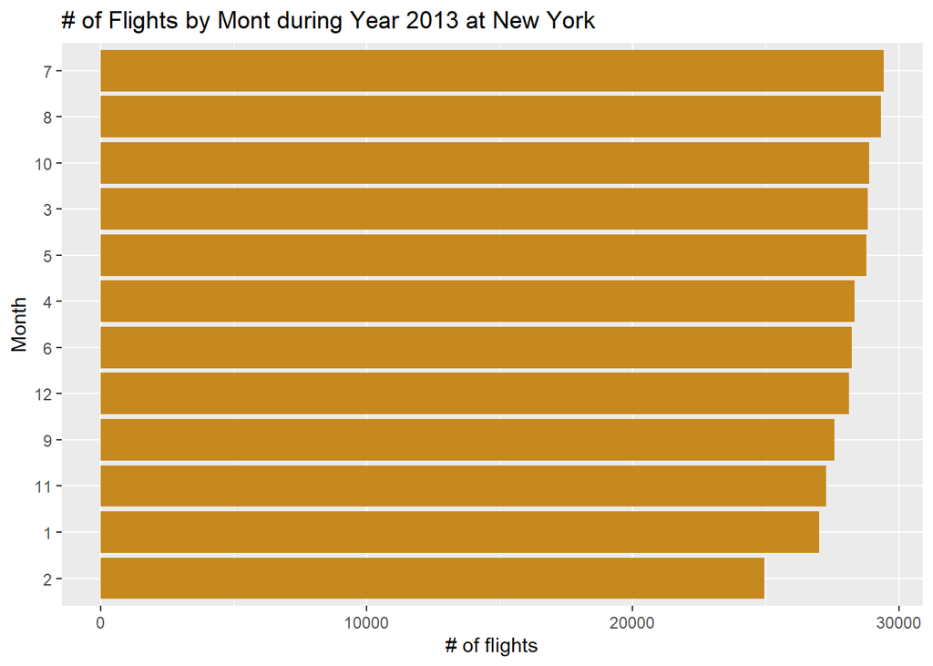

```r
 flights <- flights

 flights |>
    count(year, month) |>
     arrange(desc(n)) |>
     mutate(month = as_factor(month)) |>
     mutate(month = fct_reorder(month, n)) |>
     ggplot(aes(month, n, fill = year)) +
     geom_col(fill = "#c6891f", show.legend = FALSE) +
 coord_flip() +
    labs(
    x = "Month",
    y = "# of flights",
    title = "# of Flights by Mont during Year 2013 at New York"
  )
```